# Lab 7: Inference for Two Means using R

STAT 630, Fall 2020

We can use the function `t.test()` for two-sample t-tests and confidence intervals in R. Type `help(t.test)` into the console to read the documentation on this function. Some important arguments:

- `x`, `y`: numeric vectors of data values
- `alternative`: specifies the alternative hypothesis as `"two.sided"` (default), `"greater"`, or `"less"`
- `mu`: a number indicating the true value of the mean (or difference in means); default is 0
- `conf.level`: confidence level of the interval

## North carolina births data set

In 2004, the state of North Carolina released a large data set containing information on births recorded in this state. This data set has been of interest to medical researchers who are studying the relation between habits and practices of expectant mothers and the birth of their children. We will work with a random sample of 1,000 cases from the complete data set collected for this study.

The data set is called `ncbirths` and it can be accessed from the `openintro` library. Type `help(ncbirths)` to read the documentation on this data set in the help menu.

```r
library(openintro)
```

### Exploratory Analysis

As a first step in the analysis, we will look at some graphical and numerical summaries of the data. Of primary interest is the relationship between the mother’s smoking status and the baby’s weight.

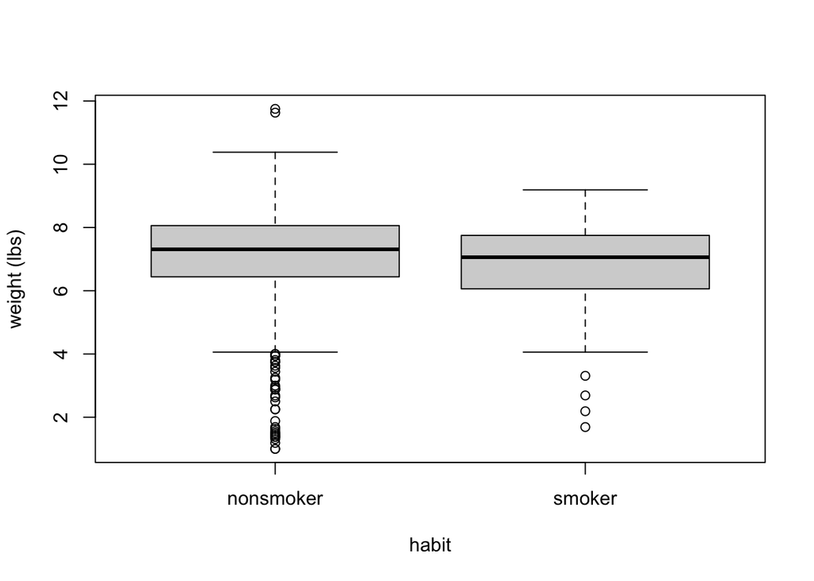

```r
boxplot(weight ~ habit, data=ncbirths, ylab="weight (lbs)")
```

```r
table(ncbirths$habit)
```

```
##
## nonsmoker    smoker
##       873       126
```